# S5_Informe3

2022-11-24

# Introducción

Una cuenca hidrográfica es el territorio de donde provienen las aguas que fluyen hacia un mismo río o mar (Instituto Mexicano de Tecnología del Agua, 2019). Por lo que, el aumento de lluvias generará un aumento del caudal.

En la región de Piura se tiene un total de 8 provincias, en la presente base se han recopilado los datos hidrometeorológicos de 4 de ellas, las cuales son Piura, Sullana, Ayabaca y Morropón

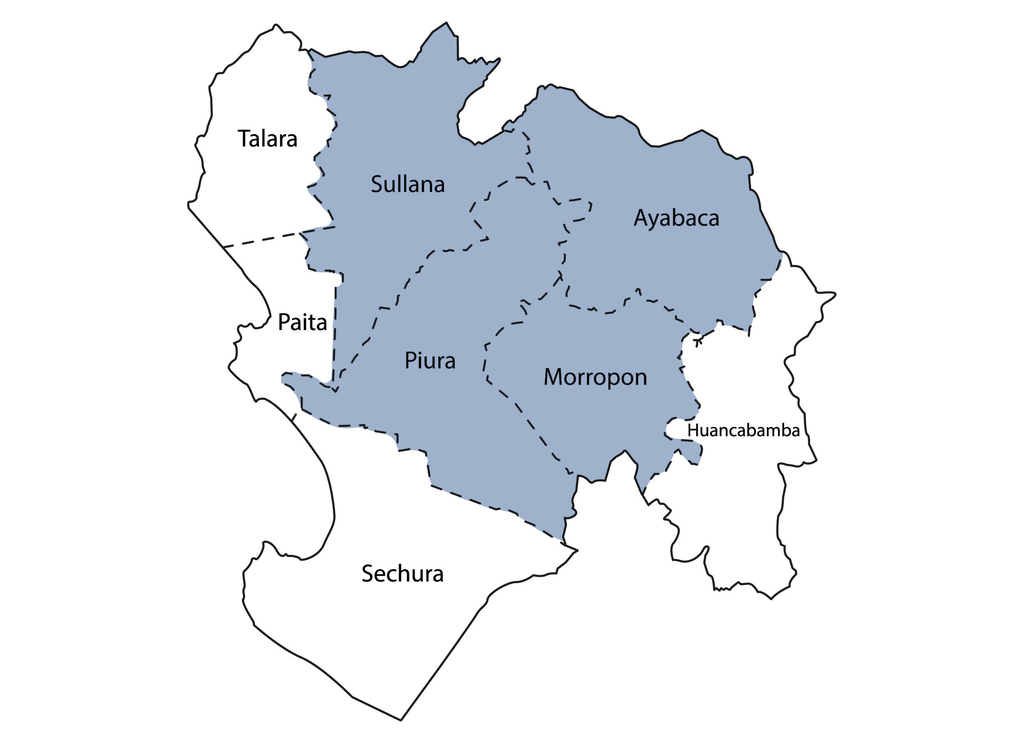

## Relevancia

Como grupo, deseamos informar sobre el impacto de las lluvias intensas en el departamento de Piura y cómo estas generan un aumento en los caudales, ya que sabemos que es uno de los departamentos más golpeados por las fuertes lluvias durante los primeros meses del año (Weather Spark, s.f.). Por ello, proporcionaremos la relación existente entre precipitaciones y caudales.

## Planificación

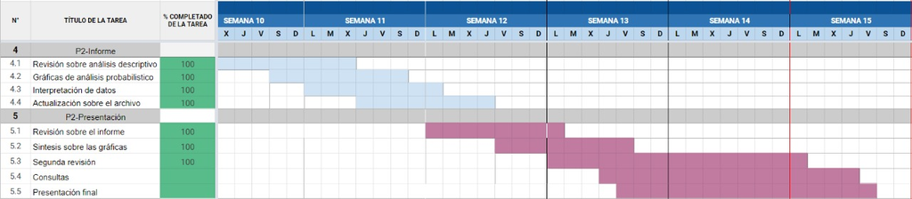

# Datos

## Recolección de datos

La recolección de datos consistió en consultar bases de datos en la [página web](https://www.datosabiertos.gob.pe/dataset/datos-hidrometereológicos-gobierno-regional-piura) oficial de datos abiertos del Perú. Con la finalidad de hallar información acerca de las precipitaciones a lo largo de los días en el departamento de Piura consultamos los datos hidrometeorológicos de dicha región. Al consultar a la plataforma nacional de datos abiertos del Perú, además de ser página gubernamental, brinda más fidelidad a los datos que brinda, extraídos directamente de las estaciones hidrográficas del departamento de Piura. Los datos son extraídos automáticamente, a la misma hora del día, mediante dispositivos tecnológicos.

## Población, muestra y muestreo

La muestra es representativa debido a la automatización del proceso para la recolección de datos dentro de las estaciones hidrográficas de Piura. La representatividad de la muestra se mantiene al tener el mínimo contacto con el ser humano. Ellos no son los que realizan las medidas, ni las registran, estas son realizadas por dispositivos de medición como el caso del pluviómetro para medir la precipitación. Los dispositivos de medición están programados por igual alrededor de todas las estaciones, midiendo el caudal a la misma hora también. Con el fin de evitar sesgos en la muestra tomaremos el tamaño total de la población de 6723 y el total de la muestra 5478 observaciones. Incluimos todos los datos para mantener intacta la información sobre las estaciones hidrográficas a lo largo del cuartil 3 del año actual.

## Variables

[output not shown]

## Limpieza de base de datos

Se trabajará con la base de datos HM y se excluirán algunas variables que no fueron usadas en el análisis del proyecto

```r
HM <- read_csv('HM.csv')

#Se excluirá la variable UBIGEO
HM %>%
  select(1,2,3,4,5,6,8,9,11,12,13,14) -> HM
HMNuevo <- HM
```

Se cambiará el nombre a la variable **CUENTA**

```r
HM  %>%
  rename(CUENCA=CUENTA) -> HMNuevo
```

Se cambió el formato de la variable **FECHA_MUESTRA** a *date* para facilitar su uso

```r
HMNuevo$Fecha_Nueva <- as.Date(as.character(HMNuevo$FECHA_MUESTRA), format = "%Y%m%d", origin="20220101")
```

Crear nueva variable **MES**

```r
HMNuevo$Mes <- format(HMNuevo$Fecha_Nueva, "%m")
```

# Análisis descriptivo

El análisis de las variables relevantes nos va a permitir un mayor conocimiento sobre el comportamiento de los caudales y las precipitaciones dentro de las diversas estaciones de Piura. Las variables numéricas nos muestran información sobre los distintos caudales y precipitaciones. En cambio, las categóricas nos permiten, además de dar claridad sobre la ubicación de los caudales medidos, categorizar las observaciones, por distrito, provincia, entre otros. Las variables relevantes para analizar son la precipitación, caudal a las 07:00, promedio del caudal, el caudal máximo, distrito y el tipo de estación.

La variable **Caudal07H** nos permite observar el cálculo del caudal cada día a la misma hora. Por otro lado, está el promedio de los caudales en otra variable **Promedio24H**. Finalmente tenemos el valor máximo del caudal cada día registrado en otra variable **Maxima24H**. Dicho caudal puede variar por distintas razones, como el clima, la vegetación de la zona, la superficie por donde recorre, etc. La información que nos da el caudal puede ser útil tanto para la construcción en ríos, como para la conservación del ecosistema del mismo.

Por otro lado, la precipitación medida dentro de la base de datos es la cantidad de agua que proviene de las nubes cada día en milímetros. Este valor también varía, generalmente, por factores naturales y del ecosistema de cada estación. Entre ellos están la latitud, distancia respecto al océano o estación de clima. Incluso el calentamiento global es un factor que afecta la precipitación. Una de las importancias del análisis de la precipitación es que se puede estimar cuándo empiezan y terminan las temporadas de lluvia. Es importante Tener en cuenta la precipitación de fechas pasadas ya que puede ser un indicador utilizado para prevenir desastres naturales. Por ejemplo, las precipitaciones extremas, y por largos periodos, son un indicador que alrededor de esa estación puede ocurrir un huayco o deslizamiento.

## Desviación estándar de las variables

Para saber cómo se dispersan los caudales y precipitaciones, y compararlos, tenemos que hacer uso de descriptores numéricos. El uso de la desviación estándar es muy conveniente a la hora de querer comparar los distintos caudales a lo largo del tiempo. Aun así, no se puede utilizar el mismo método para comparar las precipitaciones y los caudales, ya que tienen distinta unidad de medida, en milímetros y metros cúbicos respectivamente.

### Precipitaciones:

```r
sd(HMNuevo$PRECIP24H)
```

```
## [1] 2.570548
```

```r
mean(HMNuevo$PRECIP24H)
```

```
## [1] 0.1709891
```

### Promedio de los caudales al día:

```r
sd(HMNuevo$PROMEDIO24H)
```

```
## [1] 91.40799
```

```r
mean(HMNuevo$PROMEDIO24H)
```

```
## [1] 38.98421
```

### Caudales

- Caudal:

```r
sd(HMNuevo$CAUDAL07H)
```

```
## [1] 92.69008
```

```r
mean(HMNuevo$CAUDAL07H)
```

```
## [1] 40.90125
```

- Caudal maximo:

```r
sd(HMNuevo$MAXIMA24H)
```

```
## [1] 104.3355
```

```r
mean(HMNuevo$MAXIMA24H)
```

```
## [1] 45.41638
```

El promedio nos da una vista general de los caudales de los ríos a lo largo del año. Pero, si se quiere analizar un posible riesgo, nos debemos centrar en el caudal máximo, que es una posible causa de deslizamientos o huaycos. El promedio de los caudales máximos es de 45.42 m3/s. En comparación, el promedio de los caudales a las 07:00 am es de 40.90 m3/s. Se toma este valor para comparar el caudal máximo con un valor exacto más que con un promedio de un rango de valores. Esta comparación nos permite observar que aunque haya un aumento de caudal, este no es muy elevado y por lo tanto es un indicador que el aumento de caudal posiblemente no ha causado mayores desastres este año.

## Precipitación de Piura

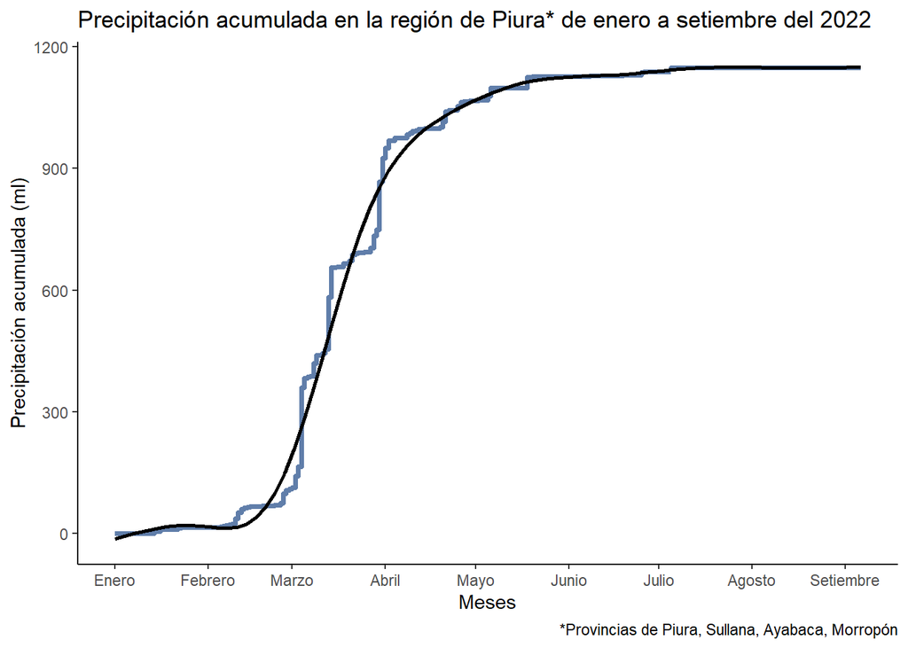

Se tiene una pendiente pronunciada en marzo, lo que indica que hubo una gran cantidad de precipitación durante esas fechas. Por otro lado, la gráfica tomó una forma lineal de enero a febrero y convergió a partir de agosto, así, entendemos que durante esos meses la lluvia es mínima.

### Precipitación mensual en Piura

Para averiguar cuál es la precipitación exacta que ha caído en cada mes, se realizará un gráfico de barras.

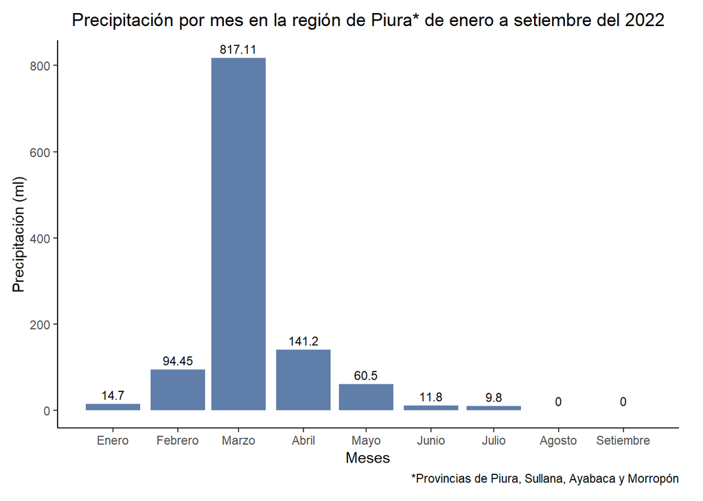

Con esta gráfica, confirmamos que es en marzo cuando cae abundante precipitación, exactamente, 817.11 ml. En cambio, a partir de agosto la precipitación baja a los 0 ml.

### Precipitación en los distritos de Piura

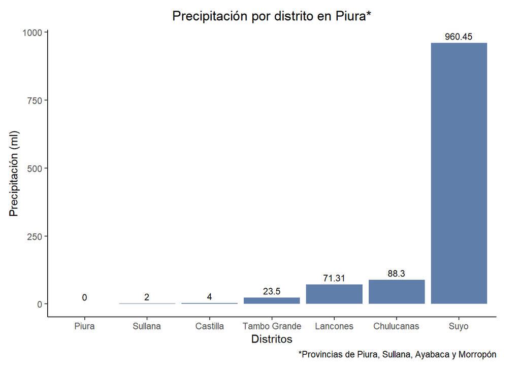

Se ordenaron los distritos de menor a mayor precipitación. Obsevamos que el distrito donde hay más es Suyo, con 960 ml. Al contrario, en el distrito de Piura hubieron 0 ml.

# Análisis probabilístico

### Aplicación 1

Si se escoge un día de marzo al azar usando los datos tomados por la estación El Ciruelo, ¿cuál será la probabilidad de que haya llovido en dicho día?

Para conseguir la probabilidad de lluvia en dicho mes, se usará el modelo de Bernoulli. Se verificará la precipitación cada día del mes, y así, se asignará como *éxito* los días donde sí ha llovido y como *fracaso* los días que no.

Primero, se encontrará la probabilidad *p* con el siguiente código

```r
#Dias totales en el mes de marzo
dMarzo <- days_in_month(as.Date("2022-03-01", "%Y-%m-%d"))

#Delimitar al distrito de Suyo, en la estacion El Cerezo y el mes de marzo
lluviaSuyo <- HMNuevo %>% filter(DISTRITO=="Suyo" & ESTACION=="EL CIRUELO" & Mes=="03")

#Contar los días de lluvia
diasDeLluvSuyo <- length(lluviaSuyo$PRECIP24H[lluviaSuyo$PRECIP24H > 0])

#Hallar la probabilidad
p <- diasDeLluvSuyo/dMarzo
p
```

```
##       Mar
## 0.5483871
```

**Precipitación diaria de El Ciruelo - Suyo en marzo**  
Para verificar que el código anterior haya dado el resultado correcto, se va a comparar la respuesta con una gráfica de barras.

Tenemos una probabilidad de 0.548 para el mes de marzo. Esta probabilidad representa 17 días aproximadamente que han llovido durante el mes. Para verificar que el código anterior haya dado el resultado correcto, se va a comparar la respuesta con una gráfica de barras.

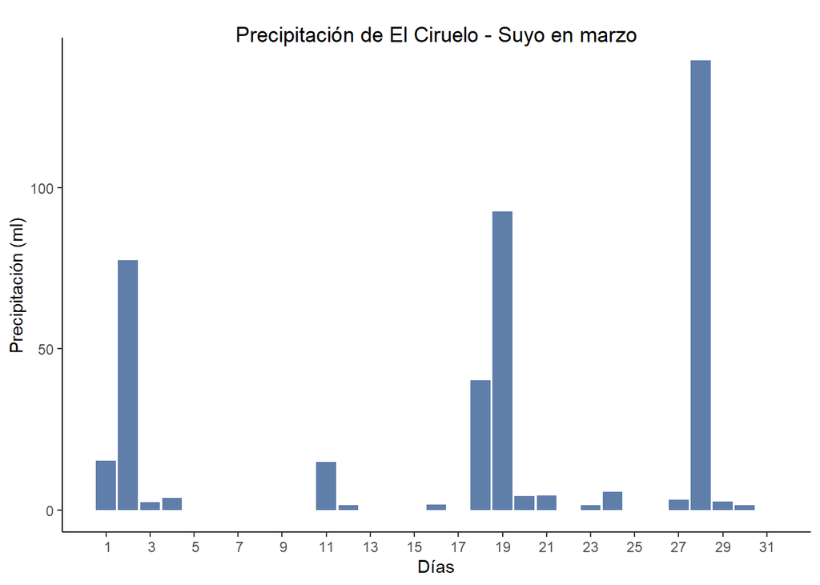

Podemos contar que hay 17 barras, lo que indica que, efectivamente, ha llovido 17 días.

**Aplicando el modelo de Bernoulli**

Se tiene la siguiente fórmula
$$\mathbb{P}(X=x)=p^x(1-p)^{n-x}$$

En donde $\mathbb(X=1)$ significa que sí llovió y $\mathbb(X=0)$ que no llovió

### Aplicación 2

Usando **p** de la *aplicación 1* ¿Cual es la probabilidad de que lluevan 15 días en todo el mes de marzo?
Para resolver esto, se usará el siguiente modelo **binomial**:
$$\mathbb{P}(X=x)=\binom{n}{x}p^x(1-p)^{n-x}$$

Se utilizará esta distribución para hallar el número de aciertos, en este caso días que llueven, dentro del total de días de marzo. Entonces, $\mathbb{P}(X=15)=\binom{31}{15}0.548^{15}(1-0.548)^{31-15}$

```r
dbinom(15, 31, 0.548)
```

```
## [1] 0.1101098
```

**Graficando el modelo binomial**

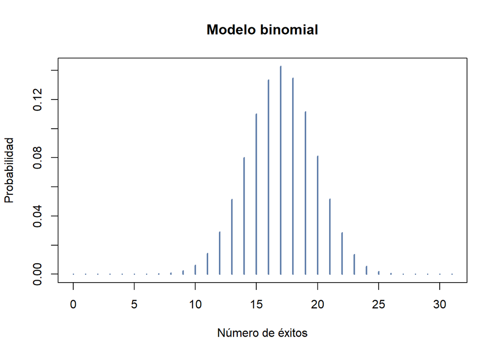

```r
plot(0:31, dbinom(0:31, 31, 0.548), type = "h", col="#607EAA", lwd=2, main = "Modelo binomial",xlab = "Número de éxitos", ylab = "Probabilidad")
```

### Aplicación 3

Usando **p** de la *aplicación 1* ¿Cuál es la probabilidad de que haya llovido por primera vez en el 4to dia?
Para resolver este ejercicio, se utilizará una **distribución geométrica**. Se usarála siguiente fórmula:
$$\mathbb{P}(X=x)=(1-p)^{x-1}p$$

Entonces, $\mathbb{P}(X=4)=(1-0.548)^{4-1}0.548$  
Para resolver esto con *dgeom* es importante recordar que R cuenta el número de fracasos, por lo que se le restara 1 a X

```r
dgeom(3,0.548)
```

```
## [1] 0.05060528
```

**Graficando el modelo geométrico**

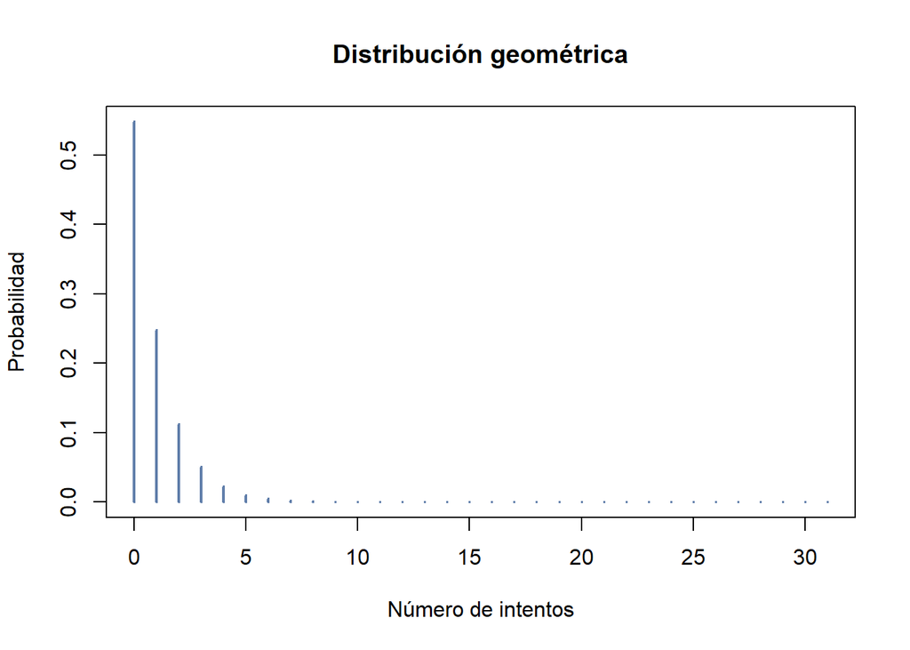

La gráfica muestra la repeticiión de un experimento Bernoulli con probabilidad de éxito fija (p = 0.548) y cuenta el número de intentos -precisamente, de fracasos- hasta lograr el primer éxito deseado. El número de intentos es infinito pero, en este caso, se colocó hasta 31 ya que ese es el total de días en marzo.

# Bibliografía

Observatorio Hidrológico del Instituto de Ingeniería de la UNAM. (2020, September 17). UNAM. Retrieved from Observatorio Hidrológico en timepo real: https://unamglobal.unam.mx/que-significa-que-se-registre-cantidades-de-lluvia-acumulada-de-hasta-100-mm/

Datos Abiertos. (06 de Setiembre de 2022). Datos Hidrometereológicos Gobierno Regional Piura. Obtenido de Plataforma Nacional de Datos Abiertos: https://www.datosabiertos.gob.pe/dataset/datos-hidrometereol%C3%B3gicos-gobierno-regional-piura